# Anscombe

Nathan M

2024-01-26

## Anscombe’s quartet

This dataset is a poignant way to demonstrate how different sets of data can appear similar with summary statistics, yet be wildly different. [The data itself](https://stat.ethz.ch/R-manual/R-devel/library/datasets/html/anscombe.html) is included in a base R installation, based on [a 1973 paper](https://doi.org/10.2307/2682899) by Francis Anscombe. However, as installed, it is not particularly well-suited for analysis or visualization.

```r
anscombe
```

```
##    x1 x2 x3 x4    y1   y2    y3    y4
## 1  10 10 10  8  8.04 9.14  7.46  6.58
## 2   8  8  8  8  6.95 8.14  6.77  5.76
## 3  13 13 13  8  7.58 8.74 12.74  7.71
## 4   9  9  9  8  8.81 8.77  7.11  8.84
## 5  11 11 11  8  8.33 9.26  7.81  8.47
## 6  14 14 14  8  9.96 8.10  8.84  7.04
## 7   6  6  6  8  7.24 6.13  6.08  5.25
## 8   4  4  4 19  4.26 3.10  5.39 12.50
## 9  12 12 12  8 10.84 9.13  8.15  5.56
## 10  7  7  7  8  4.82 7.26  6.42  7.91
## 11  5  5  5  8  5.68 4.74  5.73  6.89
```

That can be easily fixed with some simple data tidying.

```r
Anscombe <- anscombe %>%
    pivot_longer(
      everything(),
        names_to = c(".value", "set"),
        names_pattern = "(.)(.)"
    ) %>%
    arrange(set)
Anscombe
```

```
## # A tibble: 44 × 3
##    set       x     y
##    <chr> <dbl> <dbl>
##  1 1        10  8.04
##  2 1         8  6.95
##  3 1        13  7.58
##  4 1         9  8.81
##  5 1        11  8.33
##  6 1        14  9.96
##  7 1         6  7.24
##  8 1         4  4.26
##  9 1        12 10.8
## 10 1         7  4.82
## # ℹ 34 more rows
```

The demonstration starts by showing a few summary statistics, which are mostly identical, and none more than 1/100th different.

```r
Anscombe %>%
    group_by(set) %>%
    summarize(
        N = n(),
        mean.x = mean(x),
        sd.x = sd(x),
        mean.y = mean(y),
        sd.y = sd(y),
        corr.xy = cor(x, y)
    )
```

```
## # A tibble: 4 × 7
##   set       N mean.x  sd.x mean.y  sd.y corr.xy
##   <chr> <int>  <dbl> <dbl>  <dbl> <dbl>   <dbl>
## 1 1        11      9  3.32   7.50  2.03   0.816
## 2 2        11      9  3.32   7.50  2.03   0.816
## 3 3        11      9  3.32   7.5   2.03   0.816
## 4 4        11      9  3.32   7.50  2.03   0.817
```

However, by simply plotting the data, their stark differences become apparent.

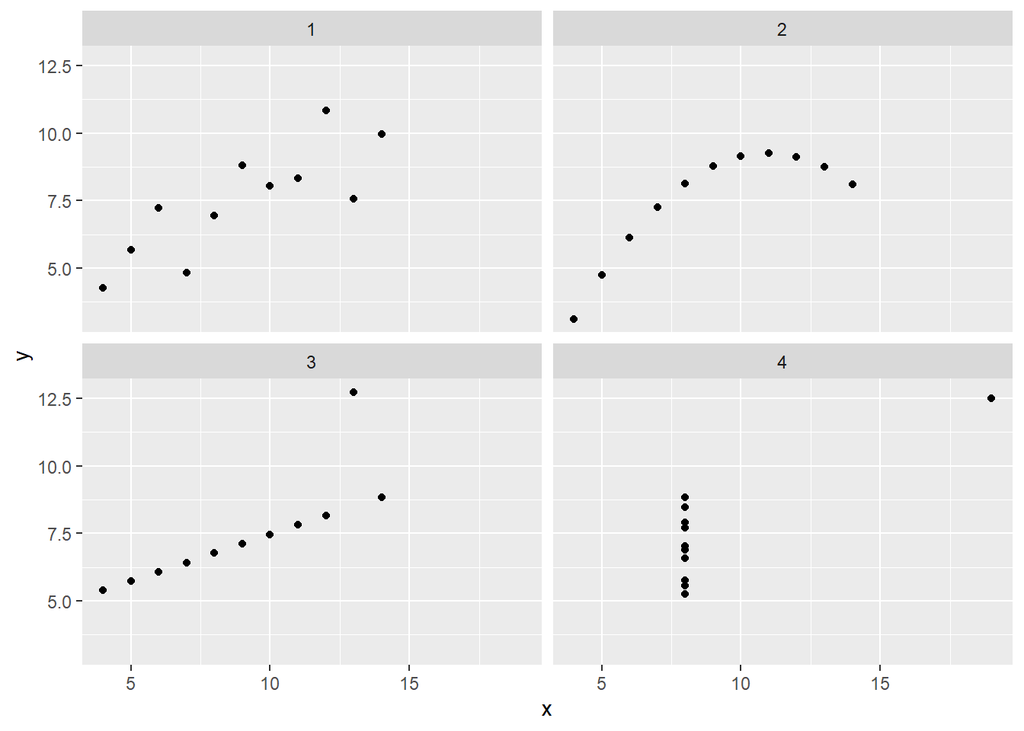

```r
ggplot(data = Anscombe, aes(x = x, y = y)) +
    geom_point() +
    facet_wrap(~ set)
```

Adding trend lines reinforces how they initially appeared similar, based only on their summary statistics.

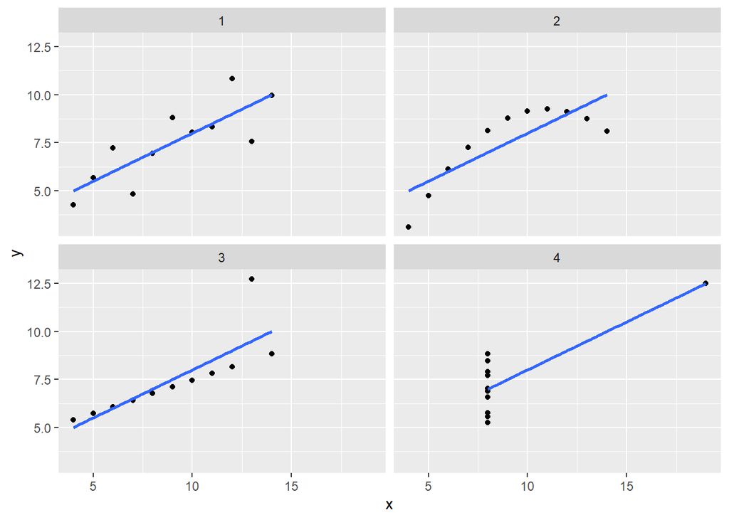

```r
ggplot(data = Anscombe, aes(x = x, y = y)) +
    geom_point() +
  geom_smooth(method = lm, se = FALSE) +
    facet_wrap(~ set)
```

This stresses the importance of data visualization in exploratory data analysis, in a way that students will remember.